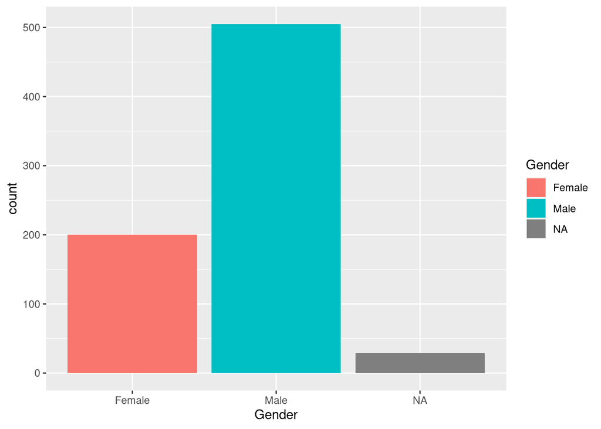

```r
ggplot(data = heroes) +
  geom_bar(aes(x = Gender, fill = Gender))
```

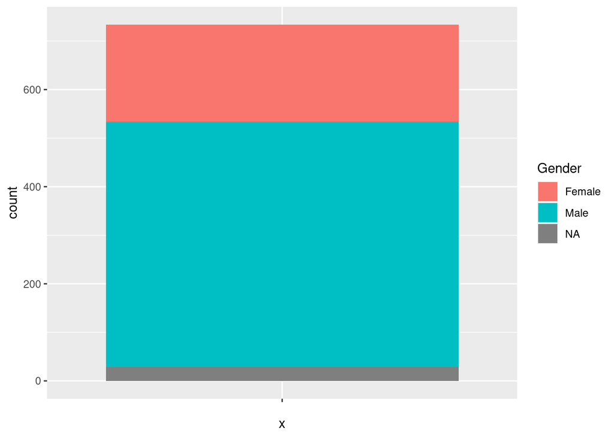

```r
ggplot(data = heroes) +
  geom_bar(aes(x = "", fill = Gender))
```

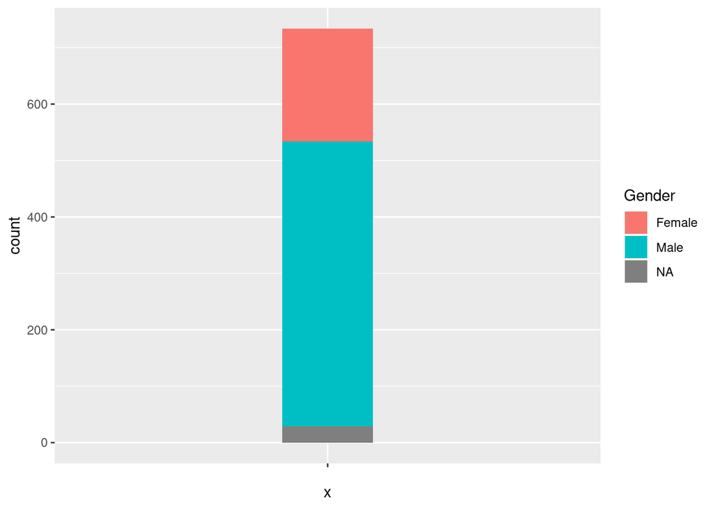

```r
ggplot(data = heroes) +
  geom_bar(aes(x = "", fill = Gender), width = .2)
```

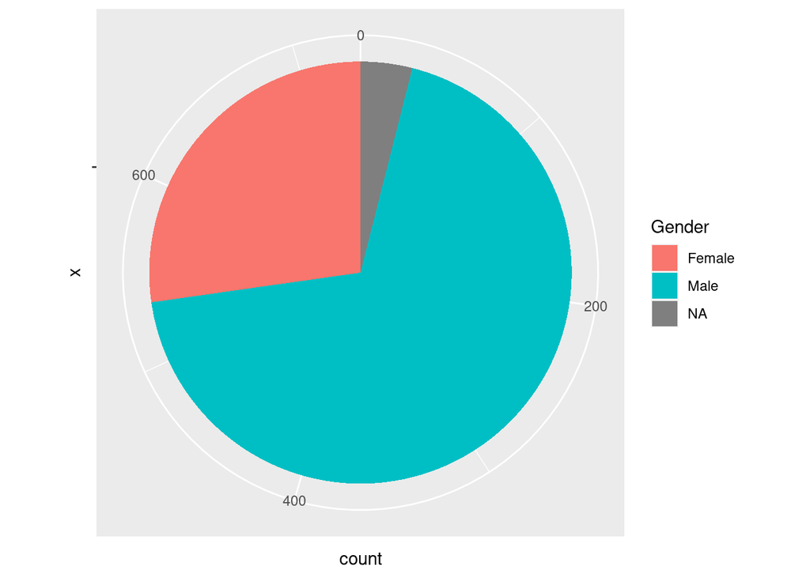

```r
ggplot(data = heroes) +
  geom_bar(aes(x = "", fill = Gender)) +
  coord_polar(theta = "y")
```

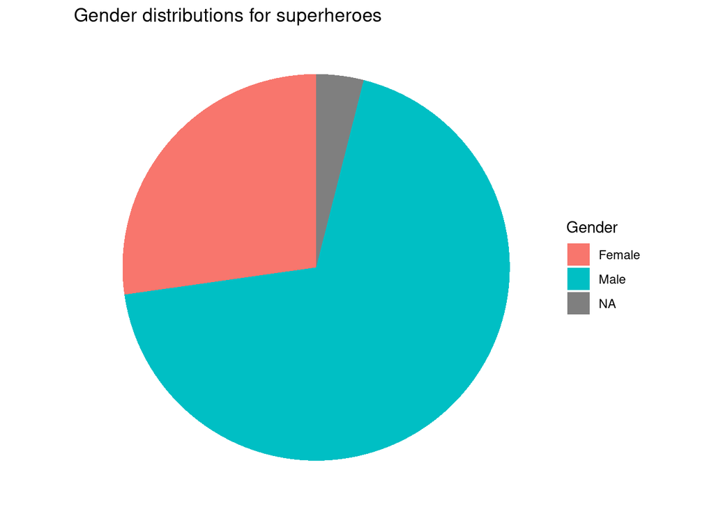

```r
ggplot(data = heroes) +
  geom_bar(aes(x = "", fill = Gender)) +
  coord_polar(theta = "y") +
  theme_void() +
  labs(title = "Gender distributions for superheroes")
```

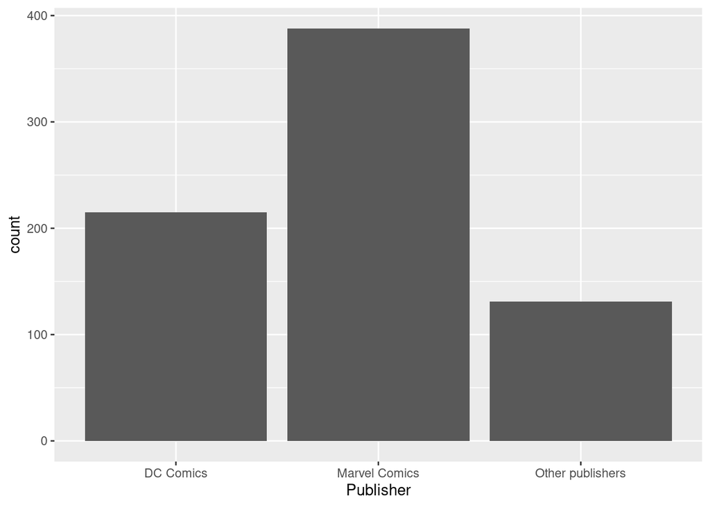

```r
heroes %>%
  mutate(Publisher = ifelse(Publisher %in% c("Marvel Comics", "DC Comics"),
                            Publisher,
                            "Other publishers")) %>%
  ggplot(aes(x = Publisher)) +
  geom_bar()
```

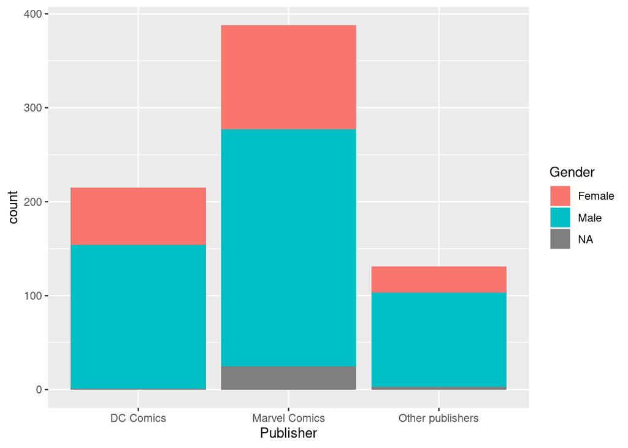

```r
heroes %>%
  mutate(Publisher = ifelse(Publisher %in% c("Marvel Comics", "DC Comics"),
                            Publisher,
                            "Other publishers")) %>%
  ggplot(aes(x = Publisher, fill = Gender)) +
  geom_bar()
```

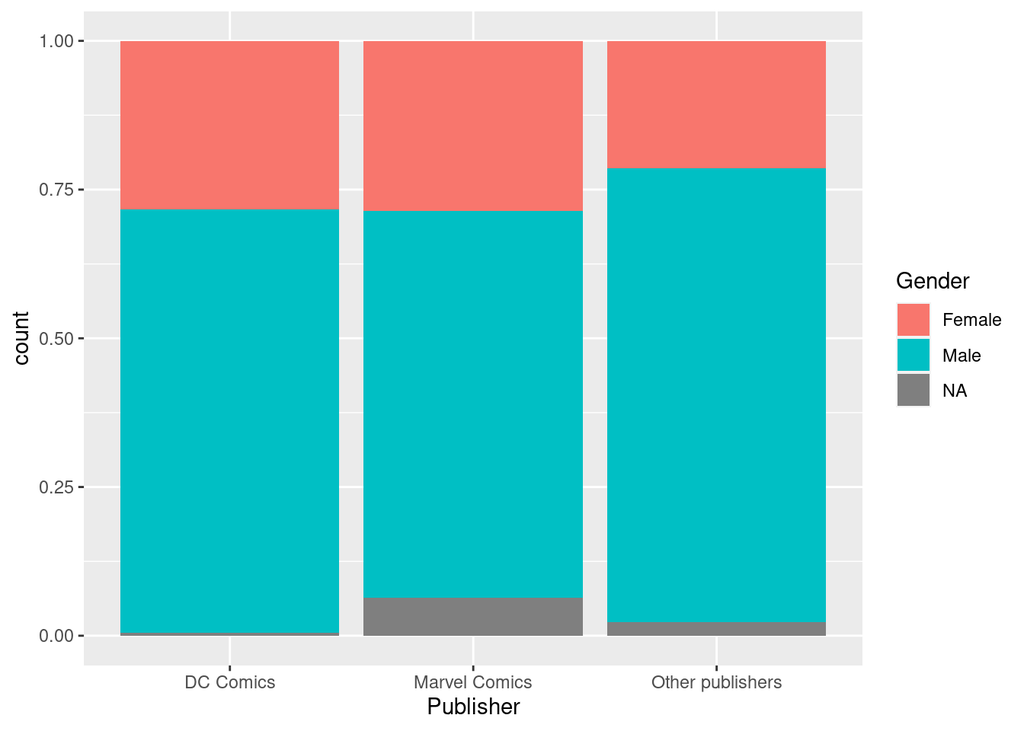

```r
heroes %>%
  mutate(Publisher = ifelse(Publisher %in% c("Marvel Comics", "DC Comics"),
                            Publisher,
                            "Other publishers")) %>%
  ggplot(aes(x = Publisher, fill = Gender)) +
  geom_bar(position = "fill")
```

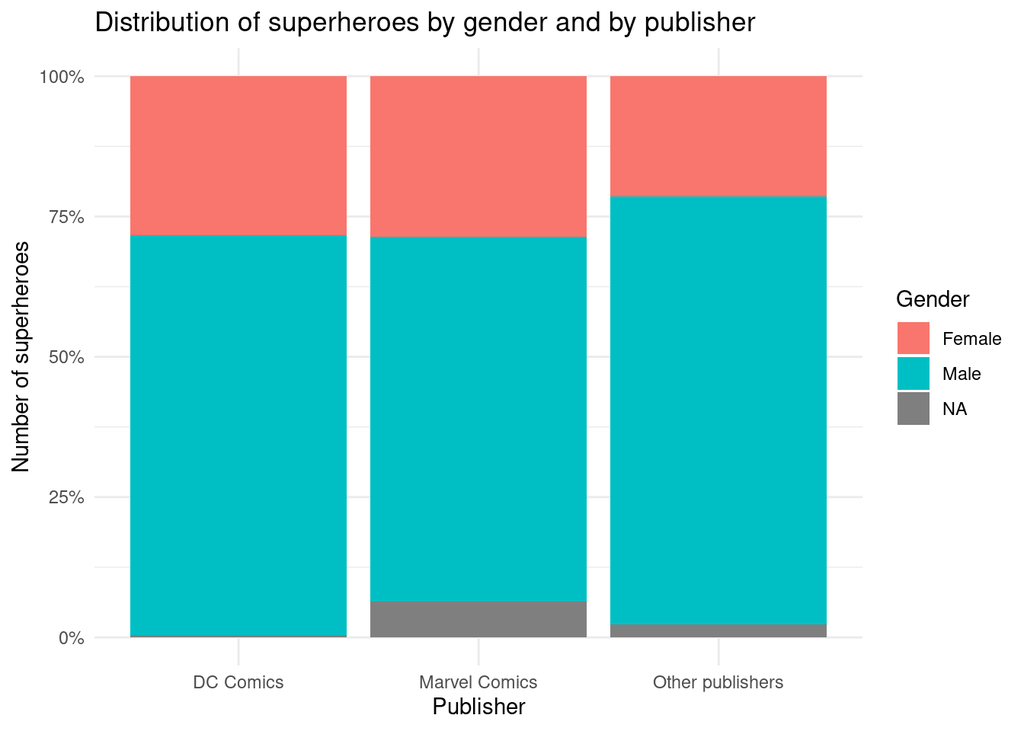

```r
heroes %>%
  mutate(Publisher = ifelse(Publisher %in% c("Marvel Comics", "DC Comics"),
                            Publisher,
                            "Other publishers")) %>%
  ggplot(aes(x = Publisher, fill = Gender)) +
  geom_bar(position = "fill") +
  labs(title = "Distribution of superheroes by gender and by publisher",
       x = "Publisher",
       y = "Number of superheroes")+
  scale_y_continuous(labels = scales::percent) +
  theme_minimal()
```

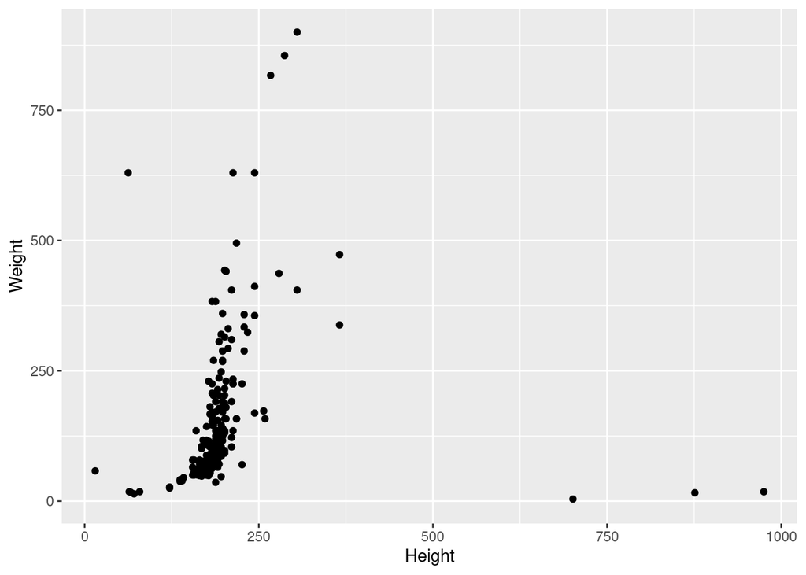

```r
heroes %>%
  ggplot(aes(x = Height, y = Weight)) +
  geom_point()
```

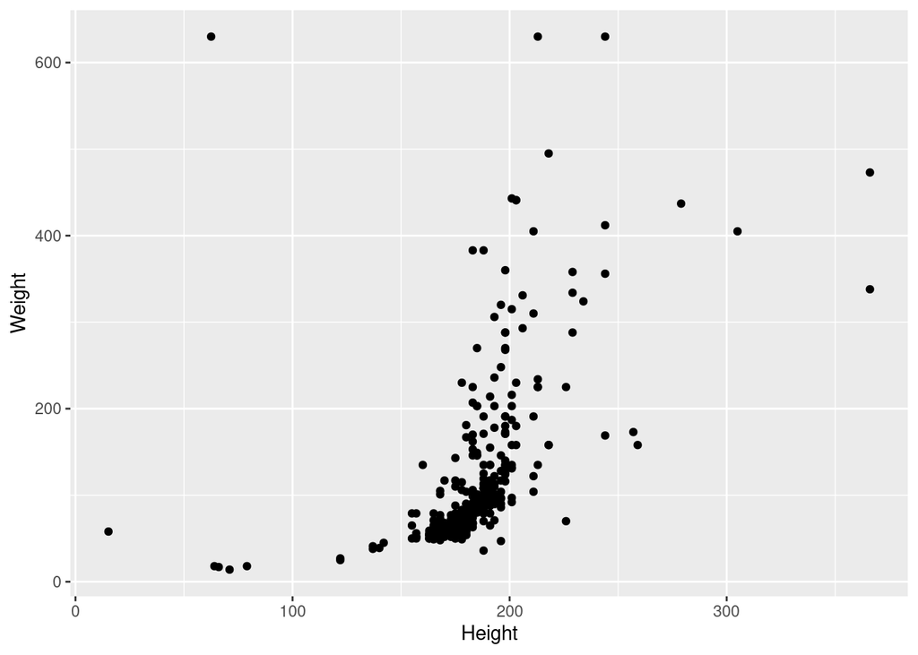

```r
heroes %>%
  filter(Weight < 700 & Height < 400) %>%
  ggplot(aes(x = Height, y = Weight)) +
  geom_point()
```

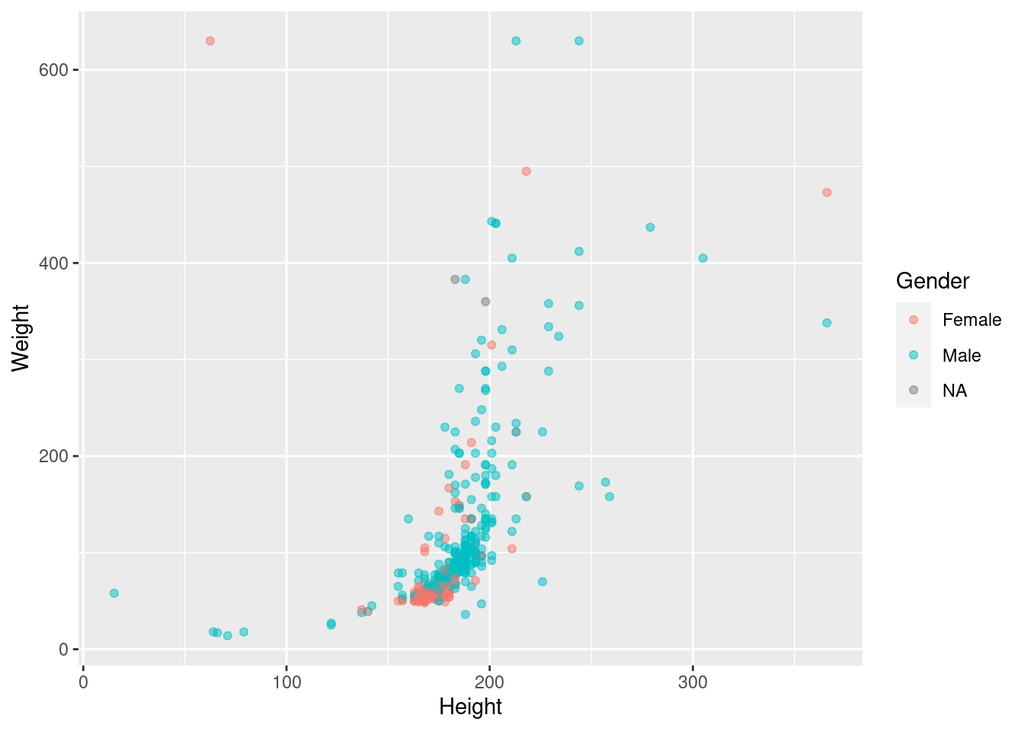

```r
heroes %>%
  filter(Weight < 700 & Height < 400) %>%
  ggplot(aes(x = Height, y = Weight)) +
  geom_point(aes(colour = Gender), alpha = 0.5)
```

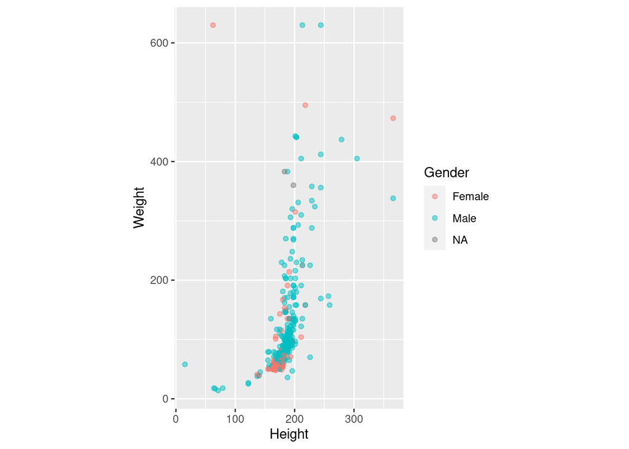

```r
heroes %>%
  filter(Weight < 700 & Height < 400) %>%
  ggplot(aes(x = Height, y = Weight)) +
  geom_point(aes(colour = Gender), alpha = 0.5) +
  coord_fixed()
```

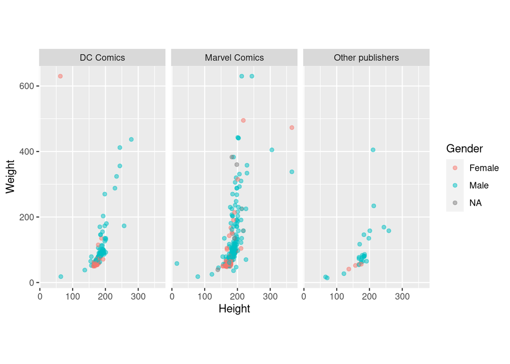

```r
heroes %>%
  mutate(Publisher = ifelse(Publisher %in% c("Marvel Comics", "DC Comics"),
                            Publisher,
                            "Other publishers")) %>%
  filter(Weight < 700 & Height < 400) %>%
  ggplot(aes(x = Height, y = Weight)) +
  geom_point(aes(colour = Gender), alpha = 0.5) +
  coord_fixed() +
  facet_wrap(~Publisher)
```

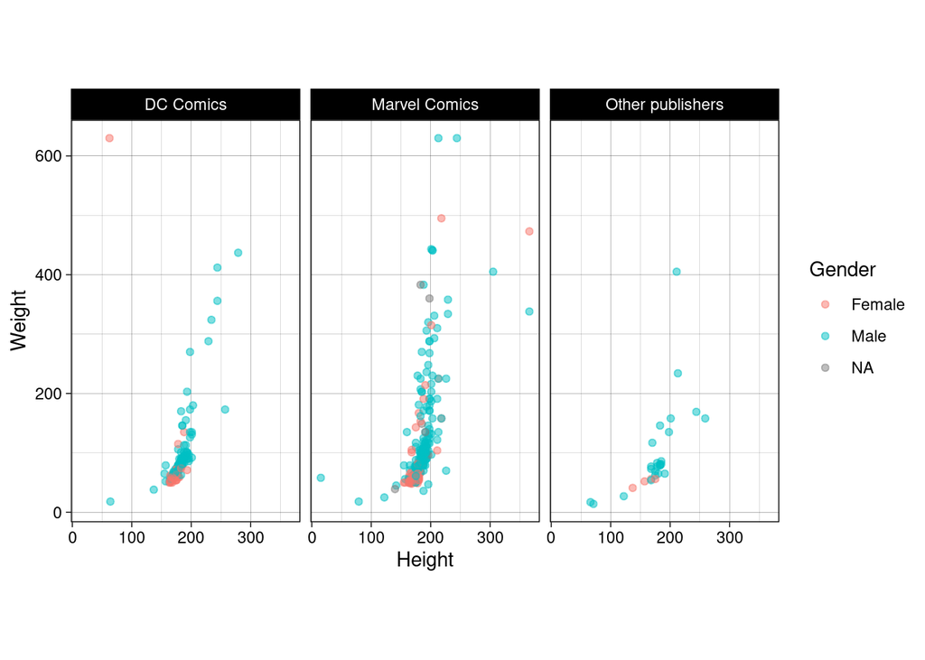

```r
heroes %>%
  mutate(Publisher = ifelse(Publisher %in% c("Marvel Comics", "DC Comics"),
                            Publisher,
                            "Other publishers")) %>%
  filter(Weight < 700 & Height < 400) %>%
  ggplot(aes(x = Height, y = Weight)) +
  geom_point(aes(colour = Gender), alpha = 0.5) +
  coord_fixed() +
  facet_wrap(~Publisher)+
  theme_linedraw()
```

#### 5. Practice

Create a tibble web_creators with superheroes who can create webs:

```r
install.packages("tidyverse")
library("tidyverse")
powers <- read_csv("https://raw.githubusercontent.com/Pozdniakov/tidy_stats/master/data/super_hero_powers.csv")
powers_web <- powers %>%
  select(hero_names, `Web Creation`)
web_creators <- left_join(heroes, powers_web, by = c("name" = "hero_names")) %>%
  filter(`Web Creation`)
web_creators
```

```
##      X              name Gender Eye.color     Race       Hair.color Height
## 1   33        Anti-Venom   Male      blue Symbiote            Blond    229
## 2   38           Arachne Female      blue    Human            Blond    175
## 3  161           Carnage   Male     green Symbiote              Red    185
## 4  335            Hybrid   Male     brown Symbiote            Black    175
## 5  479          Mysterio   Male     brown    Human          No Hair    180
## 6  580 Scarlet Spider II   Male     brown    Clone            Brown    193
## 7  597              Silk Female     brown    Human            Black     NA
## 8  620       Spider-Girl Female      blue    Human            Brown    170
## 9  621       Spider-Gwen Female      blue    Human            Blond    165
## 10 622        Spider-Man   Male     hazel    Human            Brown    178
## 11 623        Spider-Man   <NA>       red    Human            Brown    178
## 12 624        Spider-Man   Male     brown    Human            Black    157
## 13 673             Toxin   Male      blue Symbiote            Brown    188
## 14 674             Toxin   Male     black Symbiote            Blond    191
```

[output cut: 19 more lines]

All the heroes that are present in the heroes, but not in powers:

```r
anti_join(heroes, powers, by = c("name" = "hero_names")) %>%
  pull(name)
```

```
##  [1] "Agent 13"          "Alfred Pennyworth" "Arsenal"
##  [4] "Batgirl III"       "Batgirl V"         "Beetle"
##  [7] "Black Goliath"     "Black Widow II"    "Blaquesmith"
## [10] "Bolt"              "Boomer"            "Box"
## [13] "Box III"           "Captain Mar-vell"  "Cat II"
## [16] "Cecilia Reyes"     "Clea"              "Clock King"
## [19] "Colin Wagner"      "Colossal Boy"      "Corsair"
## [22] "Cypher"            "Danny Cooper"      "Darkside"
## [25] "ERG-1"             "Fixer"             "Franklin Storm"
## [28] "Giant-Man"         "Giant-Man II"      "Goliath"
## [31] "Goliath"           "Goliath"           "Guardian"
## [34] "Hawkwoman"         "Hawkwoman II"      "Hawkwoman III"
## [37] "Howard the Duck"   "Jack Bauer"        "Jesse Quick"
## [40] "Jessica Sanders"   "Jigsaw"            "Jyn Erso"
## [43] "Kid Flash II"      "Kingpin"           "Meteorite"
## [46] "Mister Zsasz"      "Mogo"              "Moloch"
## [49] "Morph"             "Nite Owl II"       "Omega Red"
## [52] "Paul Blart"        "Penance"           "Penance I"
## [55] "Plastic Lad"       "Power Man"         "Renata Soliz"
## [58] "Ronin"             "Shrinking Violet"  "Snake-Eyes"
## [61] "Spider-Carnage"    "Spider-Woman II"   "Stacy X"
## [64] "Thunderbird II"    "Two-Face"          "Vagabond"
## [67] "Vision II"         "Vulcan"            "Warbird"
## [70] "White Queen"       "Wiz Kid"           "Wondra"
## [73] "Wyatt Wingfoot"    "Yellow Claw"
```

All the heroes that are present in powers, but not in heroes:

```r
anti_join(powers, heroes, by = c("hero_names" = "name")) %>%
  pull(hero_names)
```

```
##  [1] "3-D Man"           "Bananaman"         "Bizarro-Girl"
##  [4] "Black Vulcan"      "Blue Streak"       "Bradley"
##  [7] "Clayface"          "Concrete"          "Dementor"
## [10] "Doctor Poison"     "Fire"              "Hellgramite"
## [13] "Lara Croft"        "Little Epic"       "Lord Voldemort"
## [16] "Orion"             "Peek-a-Boo"        "Queen Hippolyta"
## [19] "Reactron"          "SHDB"              "Stretch Armstrong"
## [22] "TEST"              "Tommy Clarke"      "Tyrant"
```

Create a tibble weight:

```r
heroes_weight <- heroes %>%
  filter(Publisher %in% c("DC Comics", "Marvel Comics")) %>%
  group_by(Gender, Publisher) %>%
  summarise(weight_mean = mean(Weight, na.rm = TRUE)) %>%
  drop_na()
heroes_weight
```

```
## # A tibble: 4 × 3
## # Groups:   Gender [2]
##   Gender Publisher     weight_mean
##   <chr>  <chr>               <dbl>
## 1 Female DC Comics            76.8
## 2 Female Marvel Comics        80.1
## 3 Male   DC Comics           113.
## 4 Male   Marvel Comics       134.
```

Create a wide tibble:

```r
heroes_weight %>%
  pivot_wider(names_from = "Publisher", values_from = "weight_mean")
```

```
## # A tibble: 2 × 3
## # Groups:   Gender [2]
##   Gender `DC Comics` `Marvel Comics`
##   <chr>        <dbl>           <dbl>
## 1 Female        76.8            80.1
## 2 Male         113.            134.
```

Then back to a long tibble:

```r
heroes_weight %>%
  pivot_wider(names_from = "Publisher", values_from = "weight_mean") %>%
  pivot_longer(cols = !Gender,
               names_to = "Publisher",
               values_to = "weight_mean")
```

```
## # A tibble: 4 × 3
## # Groups:   Gender [2]
##   Gender Publisher     weight_mean
##   <chr>  <chr>               <dbl>
## 1 Female DC Comics            76.8
## 2 Female Marvel Comics        80.1
## 3 Male   DC Comics           113.
## 4 Male   Marvel Comics       134.
```

Make powers a long tibble with three columns: hero_names, power (the name of the superpower) and has (whether the hero has a superpower or not):

```r
powers %>%
  pivot_longer(cols = !hero_names,
               names_to = "power",
               values_to = "has")
```

```
## # A tibble: 111,389 × 3
##    hero_names power                 has
##    <chr>      <chr>                 <lgl>
##  1 3-D Man    Agility               TRUE
##  2 3-D Man    Accelerated Healing   FALSE
##  3 3-D Man    Lantern Power Ring    FALSE
##  4 3-D Man    Dimensional Awareness FALSE
##  5 3-D Man    Cold Resistance       FALSE
##  6 3-D Man    Durability            FALSE
##  7 3-D Man    Stealth               FALSE
##  8 3-D Man    Energy Absorption     FALSE
##  9 3-D Man    Flight                FALSE
## 10 3-D Man    Danger Sense          FALSE
## # … with 111,379 more rows
```

Make tibble powers wide, but with a new structure: each row corresponds to a superpower and each column corresponds to a superhero (except for the first column – the name of the superpower):

```r
powers %>%
  pivot_longer(cols = !hero_names,
               names_to = "power",
               values_to = "has") %>%
  pivot_wider(names_from = hero_names,
              values_from = has)
```

```
## # A tibble: 167 × 668
##    power          `3-D Man` `A-Bomb` `Abe Sapien` `Abin Sur` Abomination Abraxas
##    <chr>          <lgl>     <lgl>    <lgl>        <lgl>      <lgl>       <lgl>
##  1 Agility        TRUE      FALSE    TRUE         FALSE      FALSE       FALSE
##  2 Accelerated H… FALSE     TRUE     TRUE         FALSE      TRUE        FALSE
##  3 Lantern Power… FALSE     FALSE    FALSE        TRUE       FALSE       FALSE
##  4 Dimensional A… FALSE     FALSE    FALSE        FALSE      FALSE       TRUE
##  5 Cold Resistan… FALSE     FALSE    TRUE         FALSE      FALSE       FALSE
##  6 Durability     FALSE     TRUE     TRUE         FALSE      FALSE       FALSE
##  7 Stealth        FALSE     FALSE    FALSE        FALSE      FALSE       FALSE
##  8 Energy Absorp… FALSE     FALSE    FALSE        FALSE      FALSE       FALSE
##  9 Flight         FALSE     FALSE    FALSE        FALSE      FALSE       TRUE
## 10 Danger Sense   FALSE     FALSE    FALSE        FALSE      FALSE       FALSE
## # … with 157 more rows, and 661 more variables: Absorbing Man <lgl>,
## #   Adam Monroe <lgl>, Adam Strange <lgl>, Agent Bob <lgl>, Agent Zero <lgl>,
## #   Air-Walker <lgl>, Ajax <lgl>, Alan Scott <lgl>, Alex Mercer <lgl>,
## #   Alex Woolsly <lgl>, Alien <lgl>, Allan Quatermain <lgl>, Amazo <lgl>,
## #   Ammo <lgl>, Ando Masahashi <lgl>, Angel <lgl>, Angel Dust <lgl>,
## #   Angel Salvadore <lgl>, Angela <lgl>, Animal Man <lgl>, Annihilus <lgl>,
## #   Ant-Man <lgl>, Ant-Man II <lgl>, Anti-Monitor <lgl>, Anti-Spawn <lgl>, …
```

Count NAs in each column grouping by gender:

```r
na_n <- function(x) sum(is.na(x))
heroes %>%
  group_by(Gender) %>%
  summarise(across(everything(), na_n))
```

```
## # A tibble: 3 × 11
##   Gender     X  name Eye.color  Race Hair.color Height Publisher Skin.color
##   <chr>  <int> <int>     <int> <int>      <int>  <int>     <int>      <int>
## 1 Female     0     0        41    98         38     56         0        186
## 2 Male       0     0       121   184        123    147         0        449
## 3 <NA>       0     0        10    22         11     14         0         27
## # … with 2 more variables: Alignment <int>, Weight <int>
```

```r
na_n <- function(x) sum(is.na(x))
heroes %>%
  group_by(Gender) %>%
  summarise(across(ends_with("color"), na_n))
```

```
## # A tibble: 3 × 4
##   Gender Eye.color Hair.color Skin.color
##   <chr>      <int>      <int>      <int>
## 1 Female        41         38        186
## 2 Male         121        123        449
## 3 <NA>          10         11         27
```

```r
longest_char <- function(x) x[which.max(nchar(x))]
heroes %>%
  group_by(Gender) %>%
  summarise(across(where(is.character), longest_char))
```

```
## # A tibble: 3 × 8
##   Gender name     Eye.color   Race    Hair.color  Publisher Skin.color Alignment
##   <chr>  <chr>    <chr>       <chr>   <chr>       <chr>     <chr>      <chr>
## 1 Female Negason… yellow (wi… Human … Strawberry… Dark Hor… orange     neutral
## 2 Male   Drax th… yellow / r… Dathom… Strawberry… Dark Hor… orange / … neutral
## 3 <NA>   Captain… yellow (wi… God / … Orange / W… Marvel C… grey       neutral
```

```r
higher_than_average <- function(x) ifelse(x > mean(x, na.rm = TRUE),
                                          "выше среднего",
                                          "ниже среднего")
heroes %>%
  mutate(across(c(Height, Weight),
                   higher_than_average))
```

```
##       X                      name Gender               Eye.color
## 1     0                    A-Bomb   Male                  yellow
## 2     1                Abe Sapien   Male                    blue
## 3     2                  Abin Sur   Male                    blue
## 4     3               Abomination   Male                   green
## 5     4                   Abraxas   Male                    blue
## 6     5             Absorbing Man   Male                    blue
## 7     6               Adam Monroe   Male                    blue
## 8     7              Adam Strange   Male                    blue
## 9     8                  Agent 13 Female                    blue
## 10    9                 Agent Bob   Male                   brown
## 11   10                Agent Zero   Male                    <NA>
## 12   11                Air-Walker   Male                    blue
## 13   12                      Ajax   Male                   brown
## 14   13                Alan Scott   Male                    blue
```

[output cut: 2190 more lines]

```r
heroes %>%
  group_by(Gender) %>%
  mutate(across(c(Height, Weight),
                   higher_than_average)) %>%
  ungroup() %>%
  mutate(across(c(Height, Weight),
                   ~paste(., "по", Gender)))
```

```
## # A tibble: 734 × 11
##        X name          Gender Eye.color Race  Hair.color Height Publisher Skin.color
##    <int> <chr>         <chr>  <chr>     <chr> <chr>      <chr>  <chr>     <chr>
##  1     0 A-Bomb        Male   yellow    Human No Hair    выше … Marvel C… <NA>
##  2     1 Abe Sapien    Male   blue      Icth… No Hair    ниже … Dark Hor… blue
##  3     2 Abin Sur      Male   blue      Unga… No Hair    ниже … DC Comics red
##  4     3 Abomination   Male   green     Huma… No Hair    выше … Marvel C… <NA>
##  5     4 Abraxas       Male   blue      Cosm… Black      NA по… Marvel C… <NA>
##  6     5 Absorbing Man Male   blue      Human No Hair    выше … Marvel C… <NA>
##  7     6 Adam Monroe   Male   blue      <NA>  Blond      NA по… NBC - He… <NA>
##  8     7 Adam Strange  Male   blue      Human Blond      ниже … DC Comics <NA>
##  9     8 Agent 13      Female blue      <NA>  Blond      ниже … Marvel C… <NA>
## 10     9 Agent Bob     Male   brown     Human Brown      ниже … Marvel C… <NA>
## # … with 724 more rows, and 2 more variables: Alignment <chr>, Weight <chr>
```